## 空間分析 實習四 實習提示

#### 助教 杜承軒 2020.04.12

> > 實習：描述疾病擴散的時空趨勢  
> > ＊初步環境建置與讀取檔案

> ```r
> library(rgdal);library(aspace);library(GISTools)
> setwd("D:/1082SA/Data")
> Dengue=readOGR(dsn = "point_event.shp")
> TWN=readOGR(dsn = "Popn_TWN2.shp", encoding="unicode")
> ```

> > Task 1: Exploring temporal trends in different time-scales  
> > By Week & By Period

> **1. 能創一個欄位period記錄1~7，後續會比較方便**  
> **2. 可使用barplot 或 hist 或 ggplot畫圖**  
> **3. barplot可以搭配樞紐分析函數(xtabs)**  
> **4. hist可以搭配參數breaks來調整x軸間距**

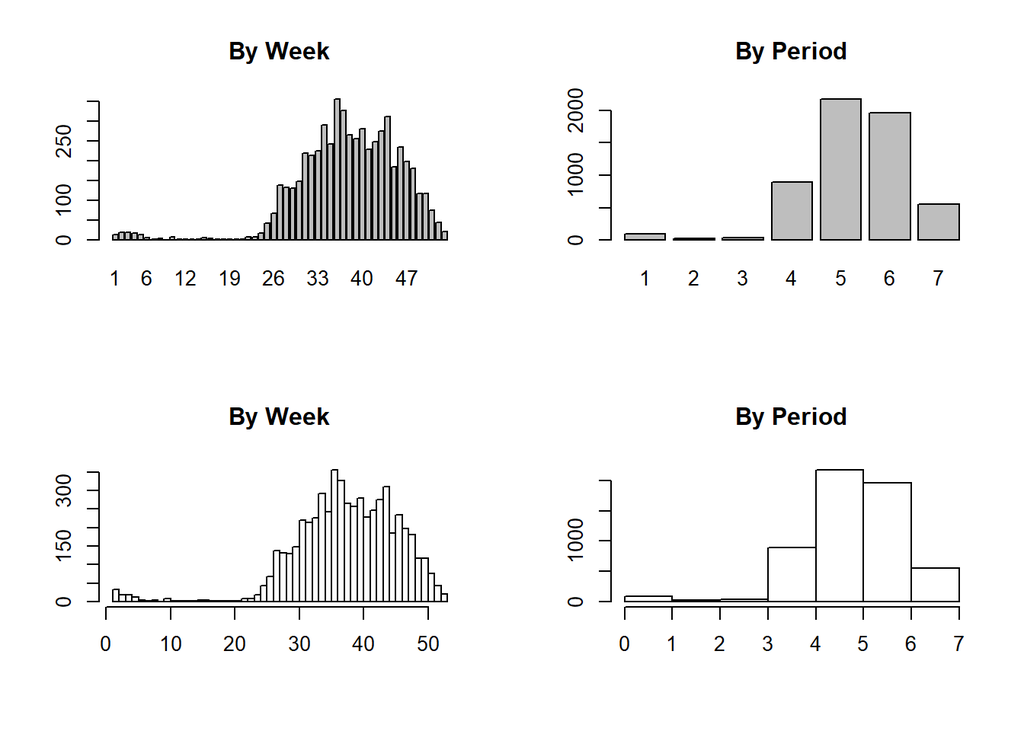

> > Task 2: Exploring spatial trends in different periods  
> > 擷取高雄地區的登革熱病例分佈

> 資料處理  
> **1. Dengue的投影座標未給定，因為確定它是TWD97TM2，可以在Dengue@proj4string或是proj4string(Dengue)，直接用等號賦予值，即Dengue@proj4string = CRS(“+proj=……”)或CRS(“+init=……”)（注意：這個步驟不是轉換座標，若要轉換座標仍要用spTransfrom）。或是用SpatialPointsDataFrame的方式新增。**  
> **2. 可使用gIntersection或是gWithin/gContain來選出高雄市的病例點位。在這之前要先抓出高雄市，可以先將高雄市dissolve成一個圖層（因為用不到鄉鎮資料），以提高執行效率(用Intersection的話可能需要會快很多)。**  
> **3. Intersect 後需要擷取下來登革熱部分的id，(思考：高雄市資料需要的要嗎？)，可以創立data.frame (因為本來Intersect後的沒有data.frame)，去搜尋原本圖資的資料再把它對回來。不過其實這些id，就代表我們要的資料在原本圖資的第幾列，也可以用原本圖資直接擷取出來。（如，第一個是高雄病例的id=195，可以從原本Dengue$X[195]、Dengue$Y[195]等等，去回找資料屬性，但其實也可以直接用Dengue[195,]擷取這個圖資。）**  
> **4. 點位可以用cbind(Dengue$x,Dengue$y)，也可以直接用Dengue@coord (點資料就會內建二維座標)**  
> **5. 使用cbind(Dengue$x,Dengue$y)，可能有整數加總溢位的問題（簡單還說就是加起來太大），到時可以先轉成numeric。**  
> **6. 各週的顏色請用看得出1~7的顏色來畫圖，如：紅橙黃綠藍靛紫，或是由淺到深的顏色漸層。**

> Standard Distance

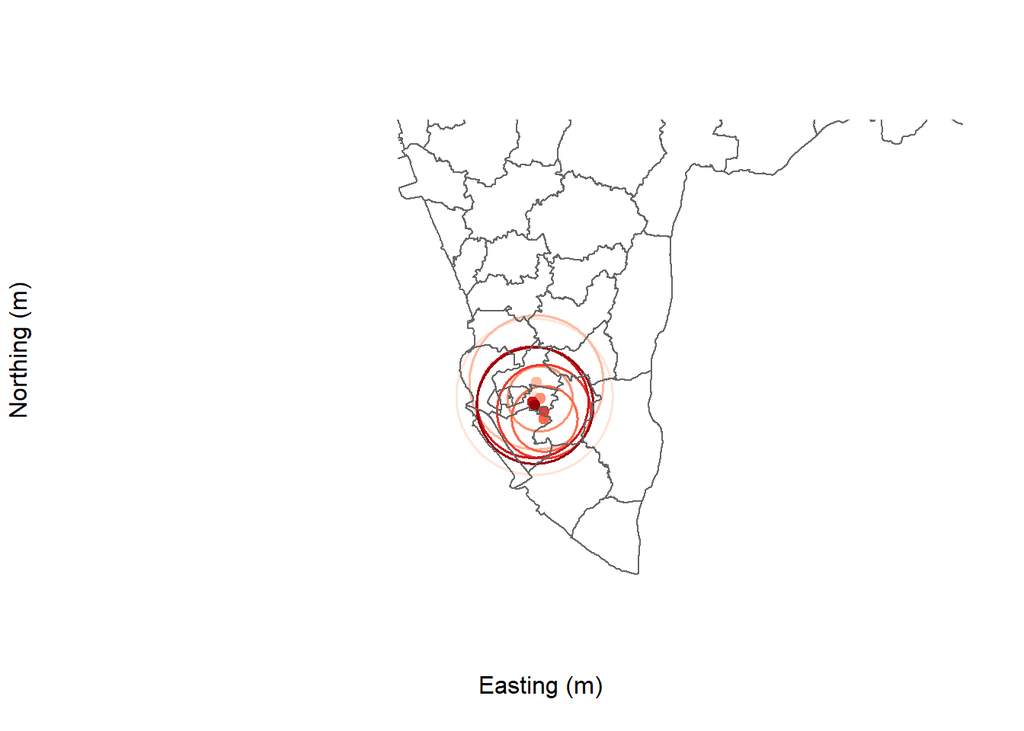

> Standard Deviational Ellipse

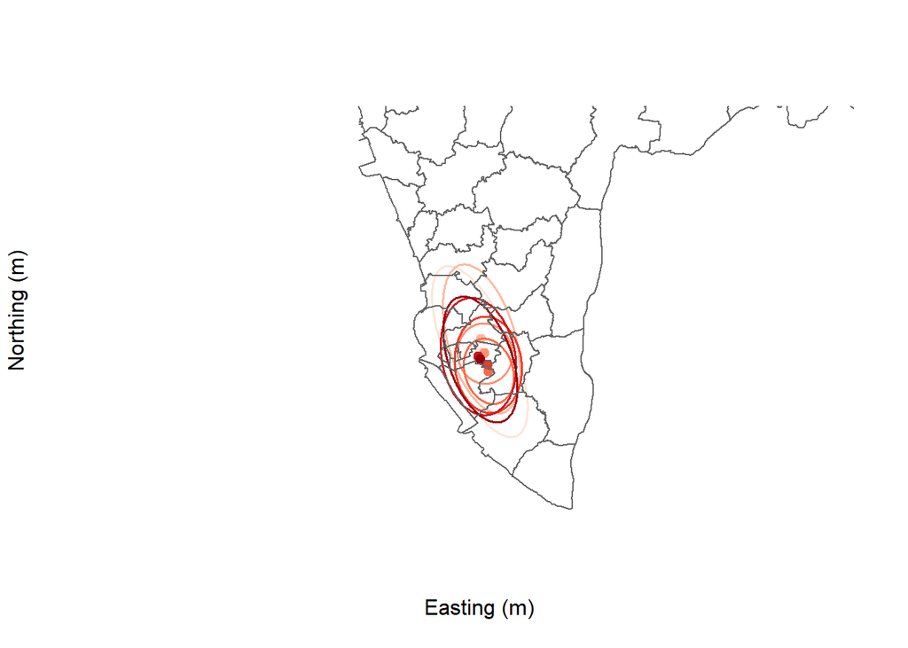